# Project4 Red Wine Quality Exploration by Jing

This report explores red wine qulity dataset containing 1599 red wines with 11 variables on the chemical properties of the wine.

```
## [1] 1599   13
```

```
## 'data.frame':    1599 obs. of  13 variables:
##  $ X                   : int  1 2 3 4 5 6 7 8 9 10 ...
##  $ fixed.acidity       : num  7.4 7.8 7.8 11.2 7.4 7.4 7.9 7.3 7.8 7.5 ...
##  $ volatile.acidity    : num  0.7 0.88 0.76 0.28 0.7 0.66 0.6 0.65 0.58 0.5 ...
##  $ citric.acid         : num  0 0 0.04 0.56 0 0 0.06 0 0.02 0.36 ...
##  $ residual.sugar      : num  1.9 2.6 2.3 1.9 1.9 1.8 1.6 1.2 2 6.1 ...
##  $ chlorides           : num  0.076 0.098 0.092 0.075 0.076 0.075 0.069 0.065 0.073 0.071 ...
##  $ free.sulfur.dioxide : num  11 25 15 17 11 13 15 15 9 17 ...
##  $ total.sulfur.dioxide: num  34 67 54 60 34 40 59 21 18 102 ...
##  $ density             : num  0.998 0.997 0.997 0.998 0.998 ...
##  $ pH                  : num  3.51 3.2 3.26 3.16 3.51 3.51 3.3 3.39 3.36 3.35 ...
##  $ sulphates           : num  0.56 0.68 0.65 0.58 0.56 0.56 0.46 0.47 0.57 0.8 ...
##  $ alcohol             : num  9.4 9.8 9.8 9.8 9.4 9.4 9.4 10 9.5 10.5 ...
##  $ quality             : int  5 5 5 6 5 5 5 7 7 5 ...
```

```
##        X          fixed.acidity   volatile.acidity  citric.acid
##  Min.   :   1.0   Min.   : 4.60   Min.   :0.1200   Min.   :0.000
##  1st Qu.: 400.5   1st Qu.: 7.10   1st Qu.:0.3900   1st Qu.:0.090
##  Median : 800.0   Median : 7.90   Median :0.5200   Median :0.260
##  Mean   : 800.0   Mean   : 8.32   Mean   :0.5278   Mean   :0.271
##  3rd Qu.:1199.5   3rd Qu.: 9.20   3rd Qu.:0.6400   3rd Qu.:0.420
##  Max.   :1599.0   Max.   :15.90   Max.   :1.5800   Max.   :1.000
##  residual.sugar     chlorides       free.sulfur.dioxide
##  Min.   : 0.900   Min.   :0.01200   Min.   : 1.00
##  1st Qu.: 1.900   1st Qu.:0.07000   1st Qu.: 7.00
##  Median : 2.200   Median :0.07900   Median :14.00
##  Mean   : 2.539   Mean   :0.08747   Mean   :15.87
##  3rd Qu.: 2.600   3rd Qu.:0.09000   3rd Qu.:21.00
##  Max.   :15.500   Max.   :0.61100   Max.   :72.00
##  total.sulfur.dioxide    density             pH          sulphates
##  Min.   :  6.00       Min.   :0.9901   Min.   :2.740   Min.   :0.3300
##  1st Qu.: 22.00       1st Qu.:0.9956   1st Qu.:3.210   1st Qu.:0.5500
##  Median : 38.00       Median :0.9968   Median :3.310   Median :0.6200
##  Mean   : 46.47       Mean   :0.9967   Mean   :3.311   Mean   :0.6581
##  3rd Qu.: 62.00       3rd Qu.:0.9978   3rd Qu.:3.400   3rd Qu.:0.7300
##  Max.   :289.00       Max.   :1.0037   Max.   :4.010   Max.   :2.0000
##     alcohol         quality
##  Min.   : 8.40   Min.   :3.000
##  1st Qu.: 9.50   1st Qu.:5.000
##  Median :10.20   Median :6.000
##  Mean   :10.42   Mean   :5.636
##  3rd Qu.:11.10   3rd Qu.:6.000
##  Max.   :14.90   Max.   :8.000
```

```
##  [1] "X"                    "fixed.acidity"        "volatile.acidity"
##  [4] "citric.acid"          "residual.sugar"       "chlorides"
##  [7] "free.sulfur.dioxide"  "total.sulfur.dioxide" "density"
## [10] "pH"                   "sulphates"            "alcohol"
## [13] "quality"
```

The dataset consists 13 variables, with 1599 observations.

# Univariate Plots Section

I am interested in the question : what determine the quality of wine? In order to answer this question, I decided to look through all the features one by one. First of all, I would like to go through the distribution of wine quality. (All the data in this report are with the unit of g/dm^3 if not specified.)

1. Quality

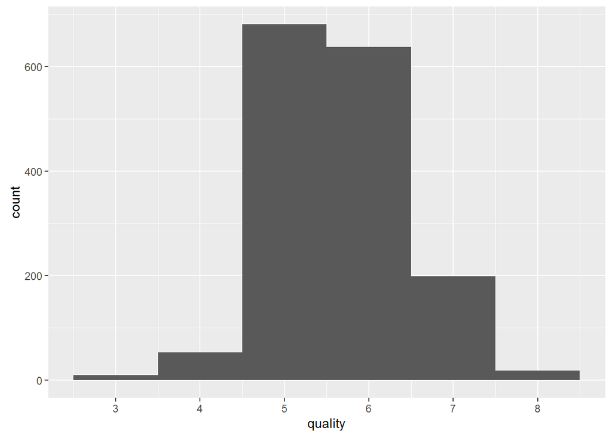

Looking through this histogram I found that most of the wine has the quality of 5 or 6. In order to better inform the histogram, I added the counts data for each quality level and reset the binwidth which is shown as follows:

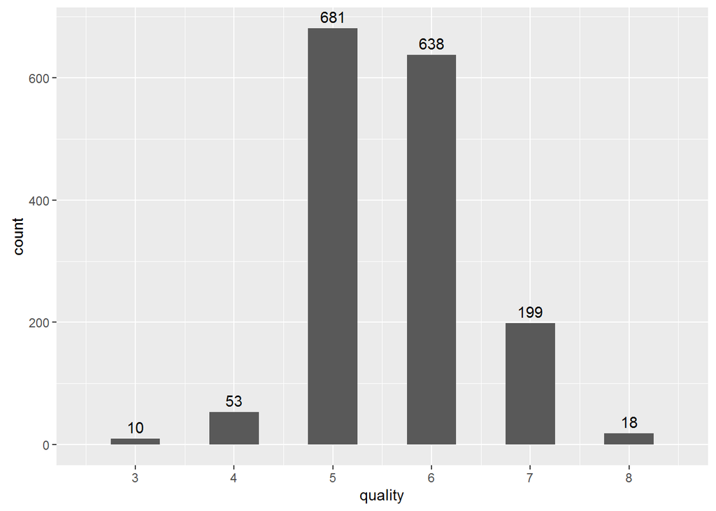

After reviewing quality data, I would like to see all the acidity and pH value distribution.

2. Acidity

First is the distribution of fixed.acidity:

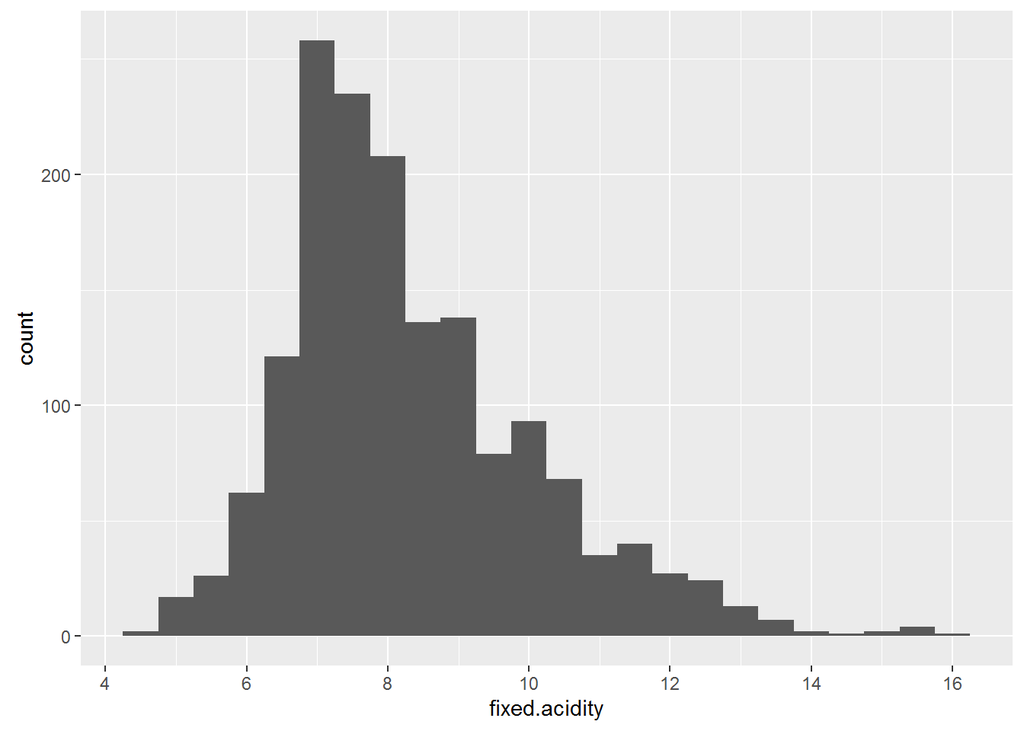

```
##    Min. 1st Qu.  Median    Mean 3rd Qu.    Max.
##    4.60    7.10    7.90    8.32    9.20   15.90
```

Look at the Histogram and table above, we could see fixed.acidity is skewed to the right with the median of 7.9.

Second is the distribution of volatile.acidity:

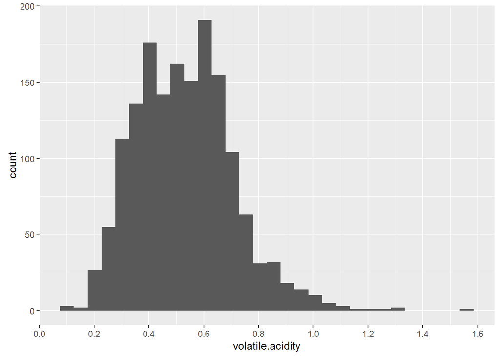

```
##    Min. 1st Qu.  Median    Mean 3rd Qu.    Max.
##  0.1200  0.3900  0.5200  0.5278  0.6400  1.5800
```

Look at the Histogram and table above, we could see volatile.acidity is also skewed to the right with the median of 0.52.

Third is the distribution of citric.acid:

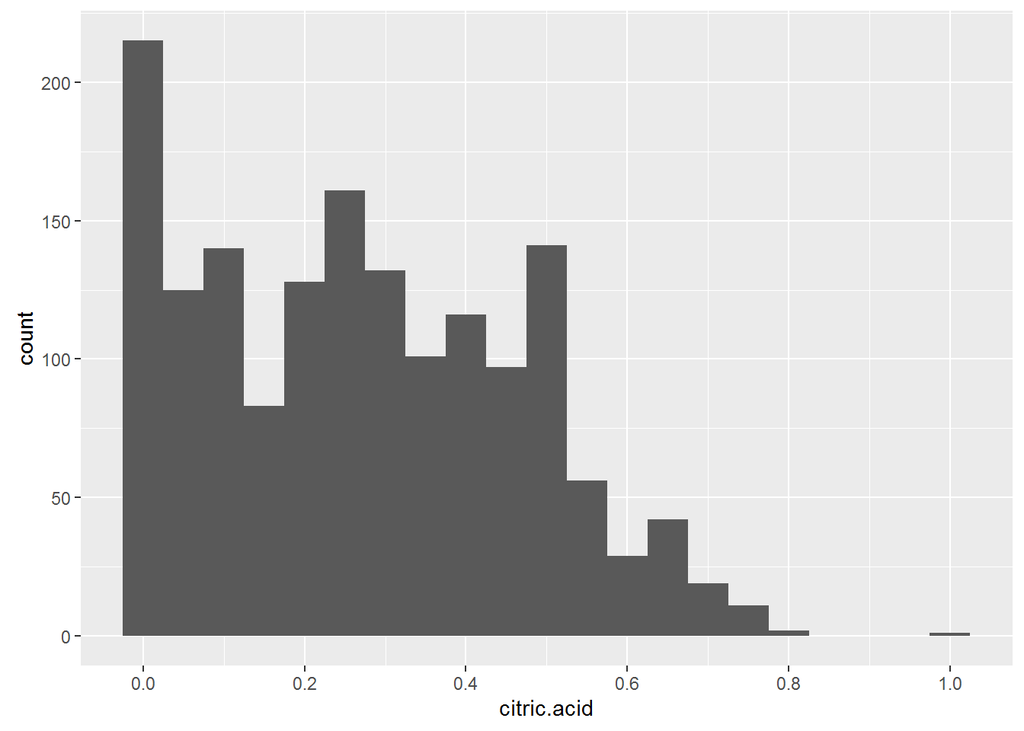

```
##    Min. 1st Qu.  Median    Mean 3rd Qu.    Max.
##   0.000   0.090   0.260   0.271   0.420   1.000
```

```
##
##    0 0.01 0.02 0.03 0.04 0.05 0.06 0.07 0.08 0.09  0.1 0.11 0.12 0.13 0.14
##  132   33   50   30   29   20   24   22   33   30   35   15   27   18   21
## 0.15 0.16 0.17 0.18 0.19  0.2 0.21 0.22 0.23 0.24 0.25 0.26 0.27 0.28 0.29
##   19    9   16   22   21   25   33   27   25   51   27   38   20   19   21
##  0.3 0.31 0.32 0.33 0.34 0.35 0.36 0.37 0.38 0.39  0.4 0.41 0.42 0.43 0.44
##   30   30   32   25   24   13   20   19   14   28   29   16   29   15   23
## 0.45 0.46 0.47 0.48 0.49  0.5 0.51 0.52 0.53 0.54 0.55 0.56 0.57 0.58 0.59
##   22   19   18   23   68   20   13   17   14   13   12    8    9    9    8
##  0.6 0.61 0.62 0.63 0.64 0.65 0.66 0.67 0.68 0.69  0.7 0.71 0.72 0.73 0.74
##    9    2    1   10    9    7   14    2   11    4    2    1    1    3    4
## 0.75 0.76 0.78 0.79    1
##    1    3    1    1    1
```

Fourth, I would like to look through the data pH which, as I know, is related to the concentration of acid:

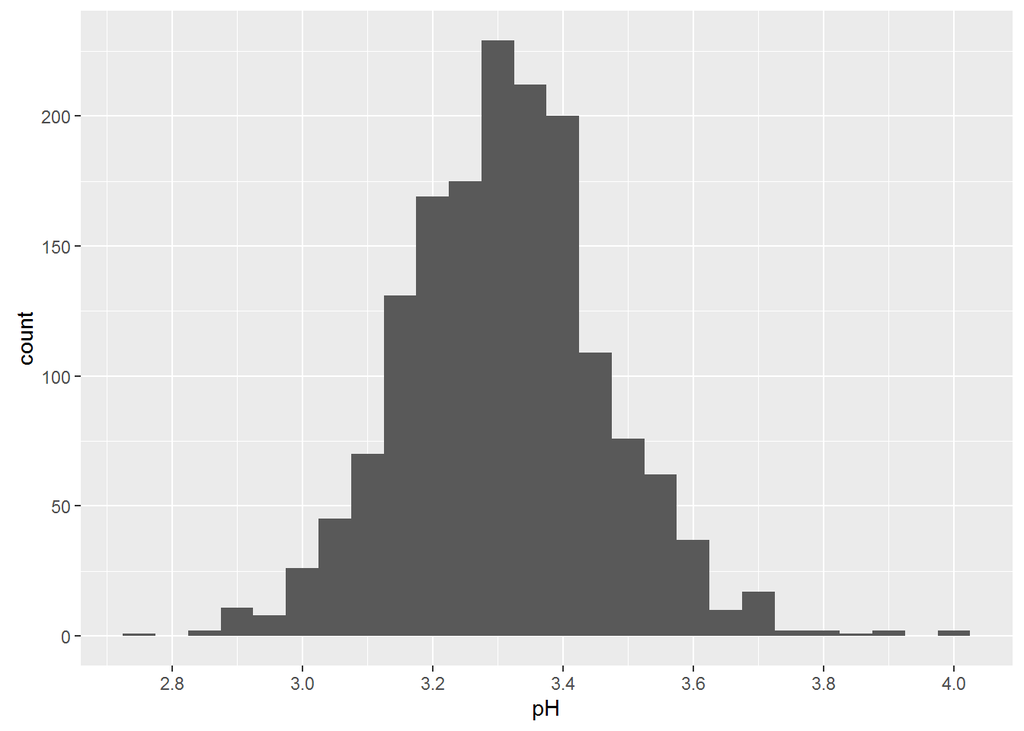

```
##    Min. 1st Qu.  Median    Mean 3rd Qu.    Max.
##   2.740   3.210   3.310   3.311   3.400   4.010
```

From the Histogram and table above, we could see pH value is almost nomaly distributed with the median and mean of around 3.31.

As I know, fixed acid, volatile acid and citric acid are all acid, so I would like to add them up to see the distribution of total acidities.

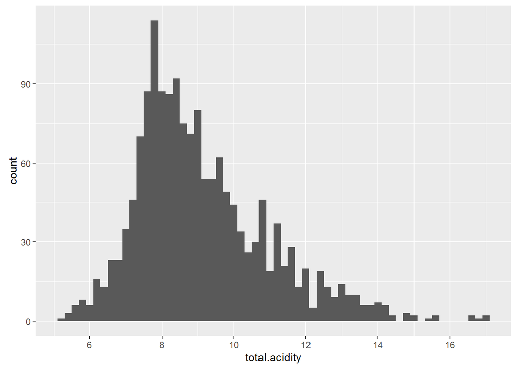

```
##    Min. 1st Qu.  Median    Mean 3rd Qu.    Max.
##   5.270   7.827   8.720   9.118  10.070  17.050
```

From the Histogram and table above, we could see the total acidity is skewed to right a little bit with median of 8.72 which is in the expectation.

3. Residual sugar

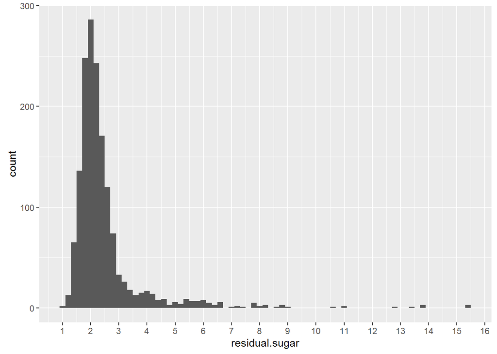

```
##    Min. 1st Qu.  Median    Mean 3rd Qu.    Max.
##   0.900   1.900   2.200   2.539   2.600  15.500
```

From the Histogram and table above, we could see most wine contain sugar between 1.9 to 2.6. The sugar plot have some outliers so let’s zoom in to have a better view.

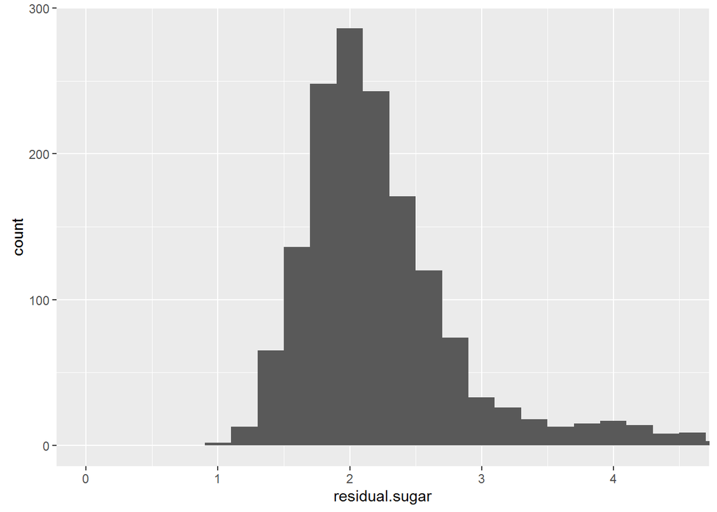

4. Chlorides

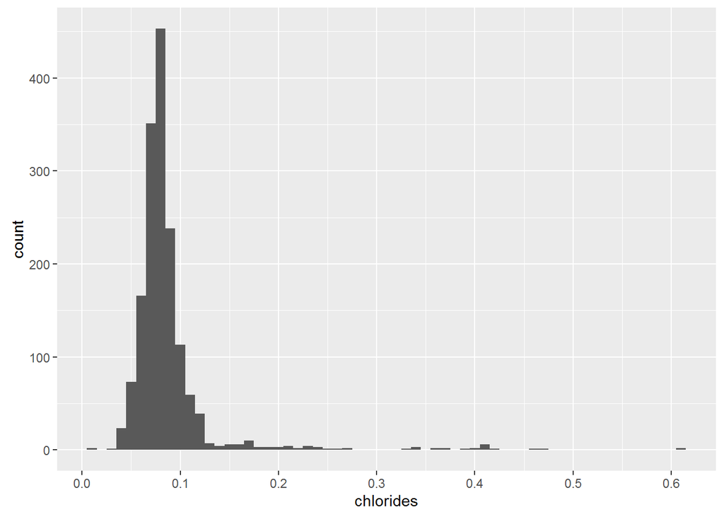

```
##    Min. 1st Qu.  Median    Mean 3rd Qu.    Max.
## 0.01200 0.07000 0.07900 0.08747 0.09000 0.61100
```

From the Histogram and table above, we could see most wine contain chlorides between 0.07 to 0.09. As same as the sugar plot, this plot also have some outliers so let’s zoom in to have a better view.

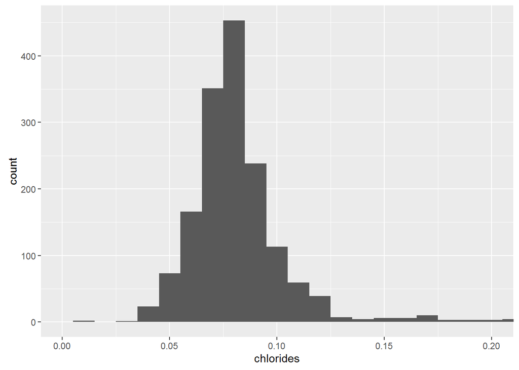

5. Sulfur.dioxide

First is for free.sulfur.dioxide:

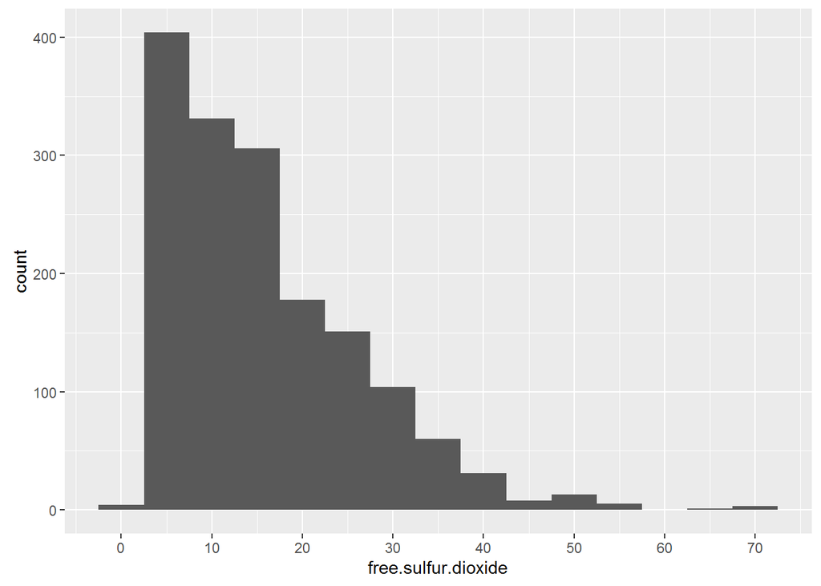

```
##    Min. 1st Qu.  Median    Mean 3rd Qu.    Max.
##    1.00    7.00   14.00   15.87   21.00   72.00
```

From the Histogram and table above, we could see the distribution of free.sulfur.dioxide is highly positive skewed with the median of 14.

Second is for total.sulfur.dioxide:

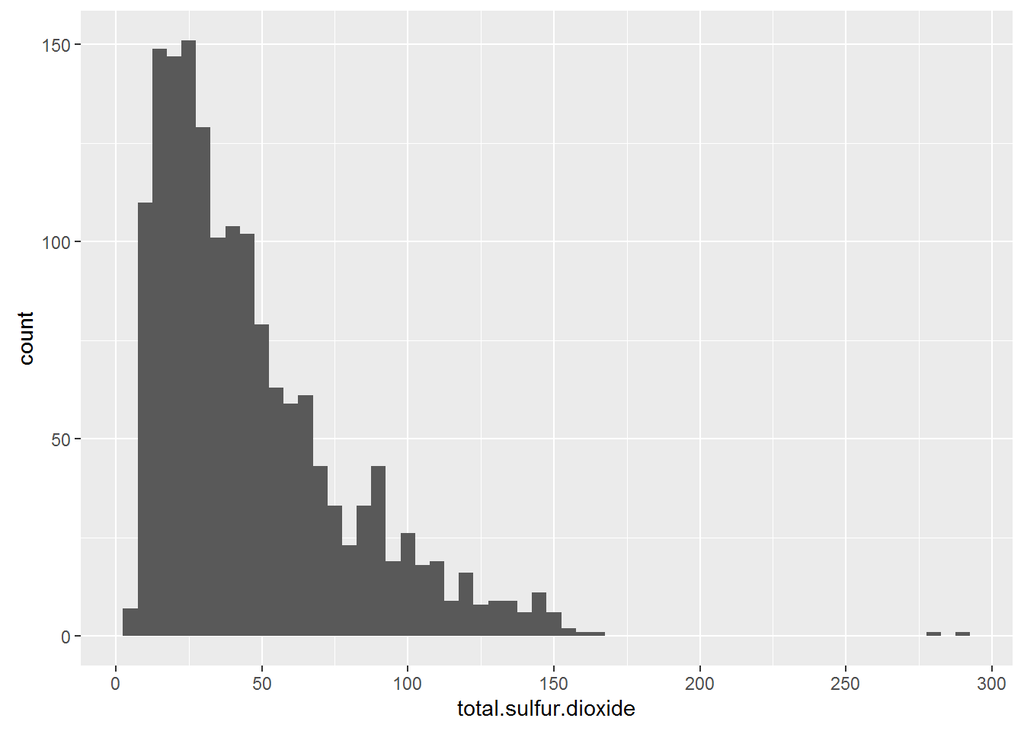

```
##    Min. 1st Qu.  Median    Mean 3rd Qu.    Max.
##    6.00   22.00   38.00   46.47   62.00  289.00
```

From the Histogram and table above, we could see the distribution of total.sulfur.dioxide is highly positive skewed with the median of 38. Also, it has some outliers, let’s zoom in.

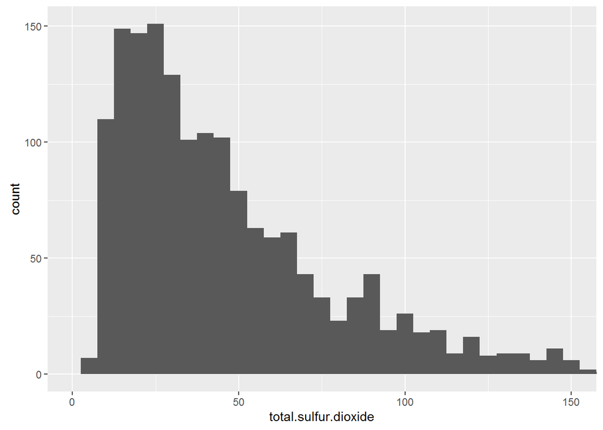

6. Density.

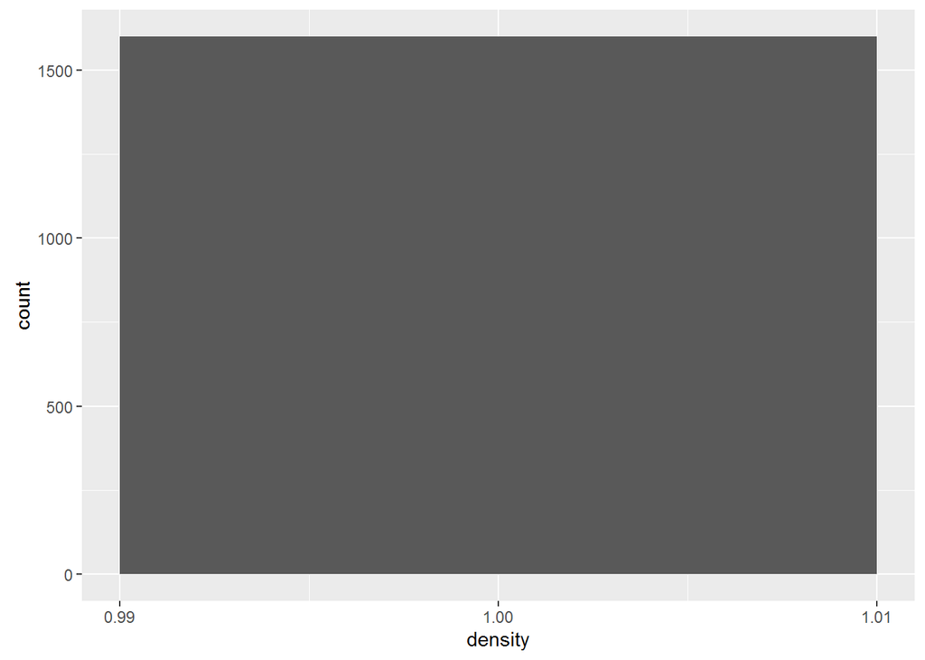

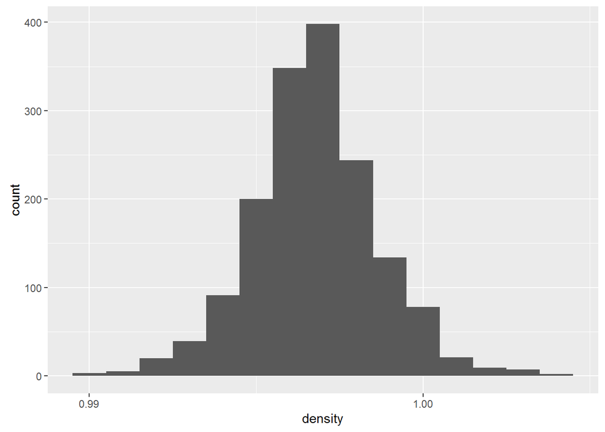

```
##    Min. 1st Qu.  Median    Mean 3rd Qu.    Max.
##  0.9901  0.9956  0.9968  0.9967  0.9978  1.0040
```

It becomes normal distribution with the mean of 0.9967 and median of 0.9968.

7. Sulphates

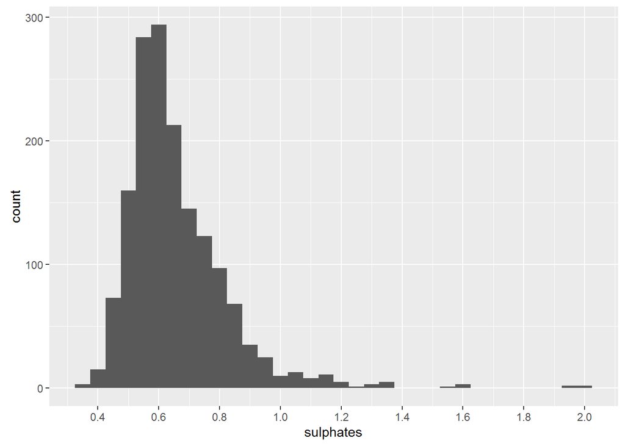

```
##    Min. 1st Qu.  Median    Mean 3rd Qu.    Max.
##  0.3300  0.5500  0.6200  0.6581  0.7300  2.0000
```

From the Histogram and table above, we could see the distribution of sulphates is positive skewed with the median of 0.62.

8. Alcohol.

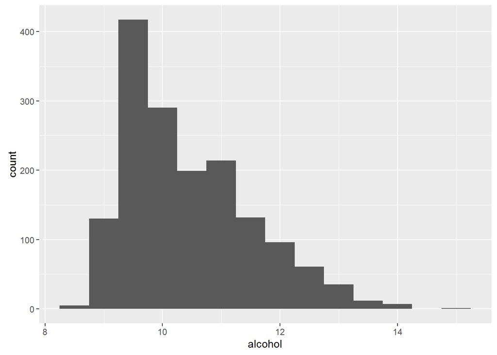

```
##    Min. 1st Qu.  Median    Mean 3rd Qu.    Max.
##    8.40    9.50   10.20   10.42   11.10   14.90
```

From the Histogram and table above, we could see the distribution of alcohol is positive skewed with the median of 10.2.

# Univariate Analysis

### What is the structure of your dataset?

There are 1599 wines in the dataset with 12 features (fixed.acidity, volatile.acidity, citric.acid, residual.sugar, chlorides, free.sulfur.dioxide, total.sulfur.dioxide, density, pH, sulphates, alcohol,quality). The variable quality is an ordinal variable with the following levels: (worst)—>(best) 0 —> 10

### What is/are the main feature(s) of interest in your dataset?

The main features in the dataset are alcohol and quality. I’d like to determine which features are best for predicting the quality of the wine. I suspect the combination of total acidity and other variables can be used to build a predictive model for wine quality.

### What other features in the dataset do you think will help support your investigation into your feature(s) of interest?

I think the sugar, acidities, sulphates and total sulfur dioxide are likely to contribute to the quality of the wine.

### Did you create any new variables from existing variables in the dataset?

Yes, I create total.acidity form existing variables using fixed.acidity, volatile.acidity and citric.acid since they are all acid and should all contribute to the total acidity which can be tasted by human.

### Of the features you investigated, were there any unusual distributions? Did you perform any operations on the data to tidy, adjust, or change the form of the data? If so, why did you do this?

Yes, I adjust the x axies for the distribtution data of residual.sugar, chlorides and total.sulfur.dioxide to rule out the outliers.

# Bivariate Plots Section

Let’s see the features of interest plotted by pairs.

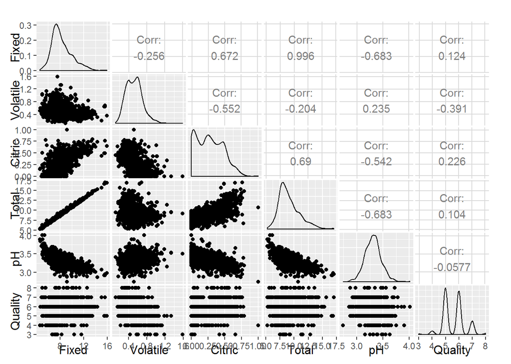

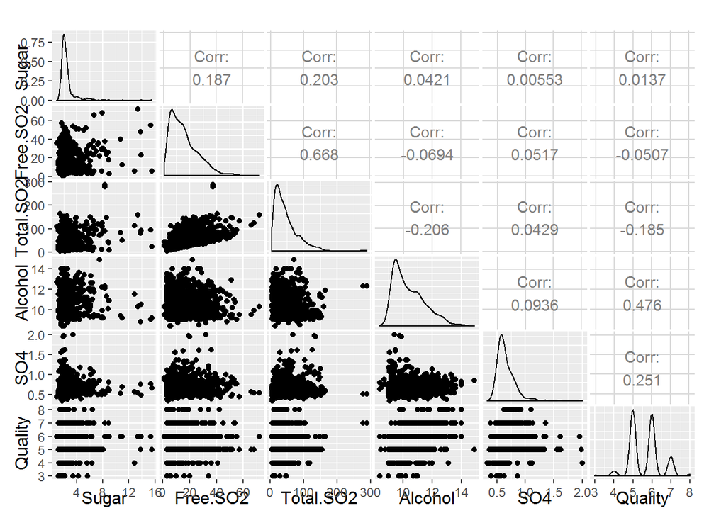

From the correlation data of above picture, I noticed that the alcohol has the strongest positive correlation with quality, which is 0.476.

Follows by volatile acid which has a negative correlation with quality, which is -0.391. This can be understood since too high levels of volatile acid can lead to an unpleasant, vinegar taste.

The next one is sulphates with the correlation of 0.251.

The next one is citric acid with the correlation of 0.226. The citric acid can add ‘freshness’ and flavor to wines.

Then follows by total sulfur dioxide with the negative correlation of -0.185.

Then follows by fixed acidity with the correlation of 0.124.

One thing surprise me is the correlation of total acidity and quality which I expected to be high. After looking through the data, I realized that the first reason is that volatile acid has a negative correlation while the other two has positive correlations. There are trade off for these three acid. Second, since the concentration of fixed acid has very high ratio in total, the total acid is acturally dominate by fixed acid. Thus, I think the total acidity feature may not be a good one to predict the quality of wine.

Right now, let’s have a closer look for the relationships of quality with the features listet above.

1. Alcohol

Here is the scatter plot of alcohol concentration for each quality levels:

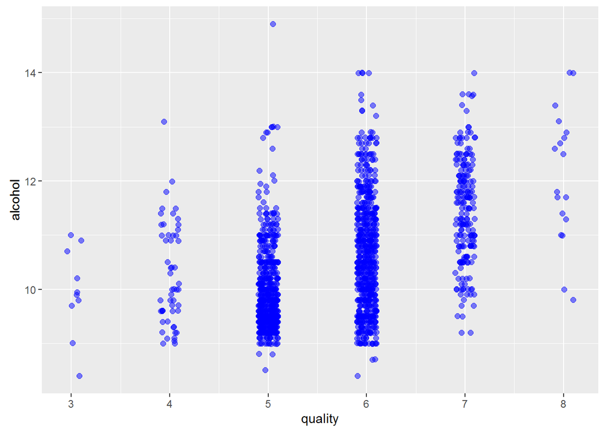

Here is the box plot of alcohol concentration for each quality levels (X is the position of mean) :

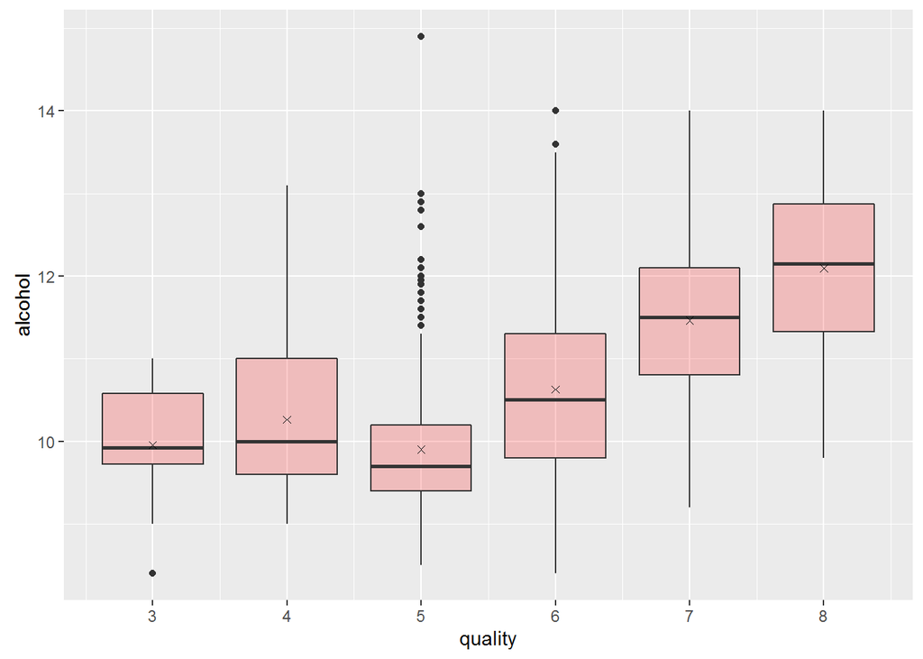

It looks like wine with higher alcohol concentraion has higher quality level espeically true when quality level is higher than 5.

The following is the statistic summary of alcohol concentration by quality level.

```
## $`3`
##    Min. 1st Qu.  Median    Mean 3rd Qu.    Max.
##   8.400   9.725   9.925   9.955  10.580  11.000
##
## $`4`
##    Min. 1st Qu.  Median    Mean 3rd Qu.    Max.
##    9.00    9.60   10.00   10.27   11.00   13.10
##
## $`5`
##    Min. 1st Qu.  Median    Mean 3rd Qu.    Max.
##     8.5     9.4     9.7     9.9    10.2    14.9
##
## $`6`
##    Min. 1st Qu.  Median    Mean 3rd Qu.    Max.
##    8.40    9.80   10.50   10.63   11.30   14.00
##
## $`7`
##    Min. 1st Qu.  Median    Mean 3rd Qu.    Max.
##    9.20   10.80   11.50   11.47   12.10   14.00
##
## $`8`
##    Min. 1st Qu.  Median    Mean 3rd Qu.    Max.
##    9.80   11.32   12.15   12.09   12.88   14.00
```

2. Volatile acidity

Here is the scatter plot of volatile acidity for each quality levels:

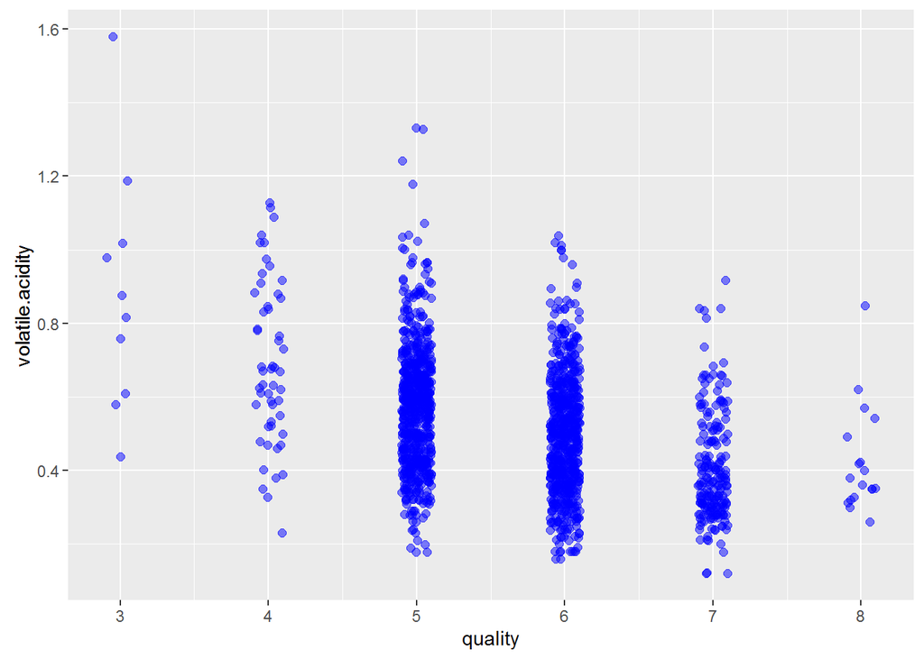

Here is the box plot of volatile acidity for each quality levels (X is the position of mean) :

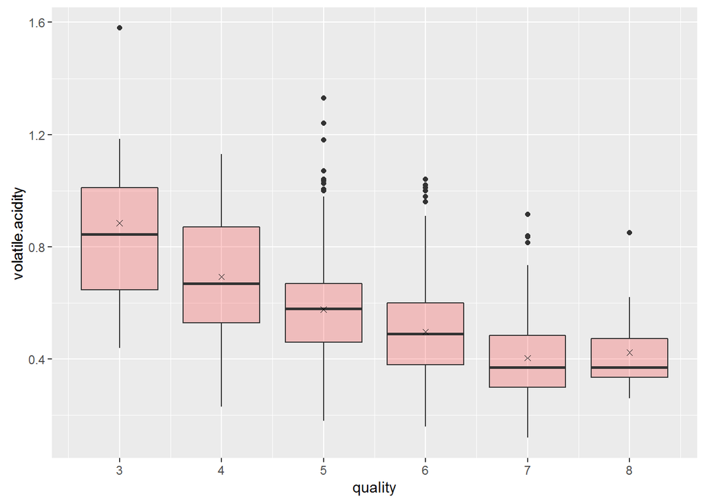

It shows a clear trend that the wine with higher volatile acidity has lower quality levels.

The following is the statistic summary of volatile acidity by quality level.

```
## $`3`
##    Min. 1st Qu.  Median    Mean 3rd Qu.    Max.
##  0.4400  0.6475  0.8450  0.8845  1.0100  1.5800
##
## $`4`
##    Min. 1st Qu.  Median    Mean 3rd Qu.    Max.
##   0.230   0.530   0.670   0.694   0.870   1.130
##
## $`5`
##    Min. 1st Qu.  Median    Mean 3rd Qu.    Max.
##   0.180   0.460   0.580   0.577   0.670   1.330
##
## $`6`
##    Min. 1st Qu.  Median    Mean 3rd Qu.    Max.
##  0.1600  0.3800  0.4900  0.4975  0.6000  1.0400
##
## $`7`
##    Min. 1st Qu.  Median    Mean 3rd Qu.    Max.
##  0.1200  0.3000  0.3700  0.4039  0.4850  0.9150
##
## $`8`
##    Min. 1st Qu.  Median    Mean 3rd Qu.    Max.
##  0.2600  0.3350  0.3700  0.4233  0.4725  0.8500
```

3. Sulphates

Here is the scatter plot of sulphates for each quality levels:

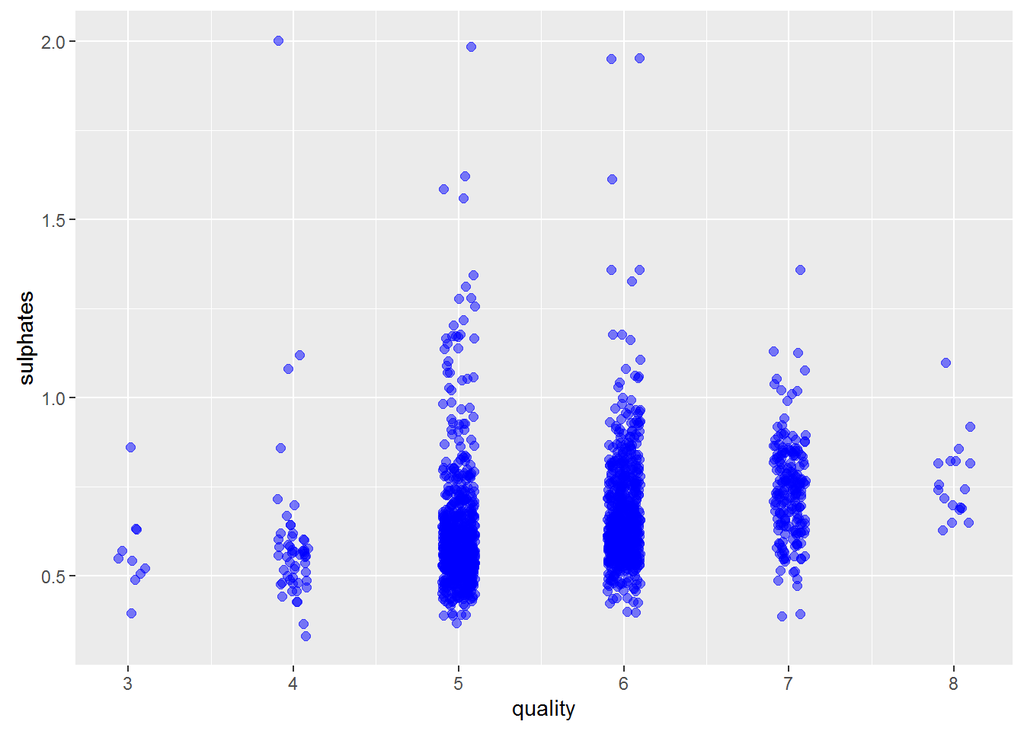

Here is the box plot of sulphates for each quality levels (X is the position of mean) :

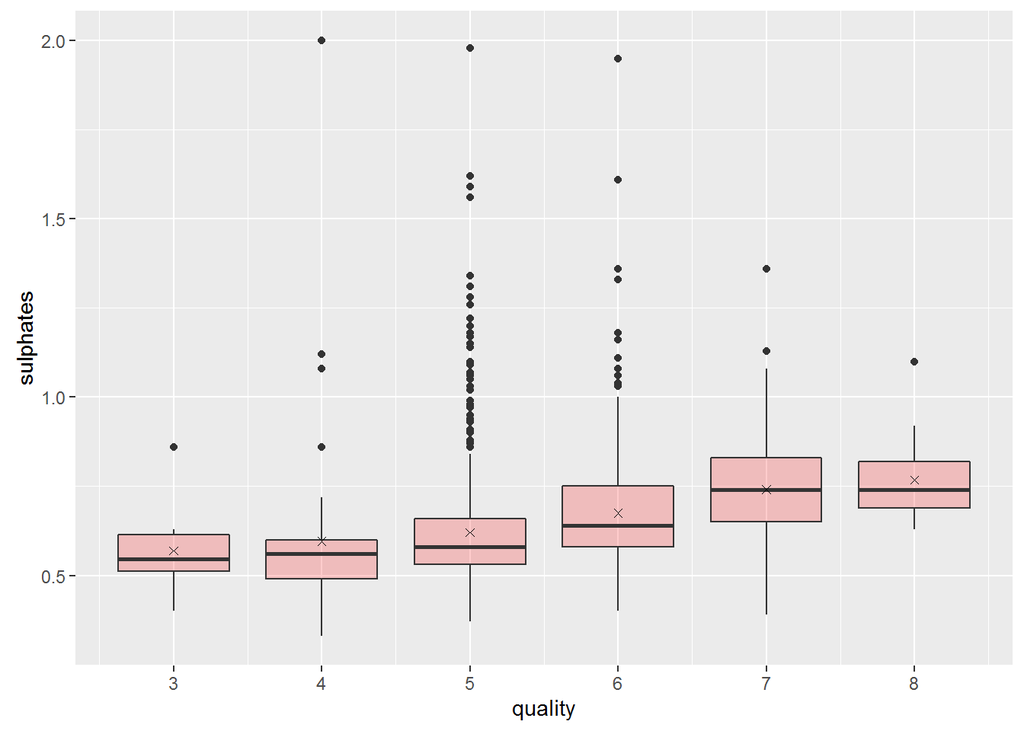

There shows likely trend that wine contain higher sulphates has higher quality level based on the statistic box plot.

The following is the statistic summary of sulphates by quality level.

```
## $`3`
##    Min. 1st Qu.  Median    Mean 3rd Qu.    Max.
##  0.4000  0.5125  0.5450  0.5700  0.6150  0.8600
##
## $`4`
##    Min. 1st Qu.  Median    Mean 3rd Qu.    Max.
##  0.3300  0.4900  0.5600  0.5964  0.6000  2.0000
##
## $`5`
##    Min. 1st Qu.  Median    Mean 3rd Qu.    Max.
##   0.370   0.530   0.580   0.621   0.660   1.980
##
## $`6`
##    Min. 1st Qu.  Median    Mean 3rd Qu.    Max.
##  0.4000  0.5800  0.6400  0.6753  0.7500  1.9500
##
## $`7`
##    Min. 1st Qu.  Median    Mean 3rd Qu.    Max.
##  0.3900  0.6500  0.7400  0.7413  0.8300  1.3600
##
## $`8`
##    Min. 1st Qu.  Median    Mean 3rd Qu.    Max.
##  0.6300  0.6900  0.7400  0.7678  0.8200  1.1000
```

4. citric acid

Here is the scatter plot of citric acide for each quality levels:

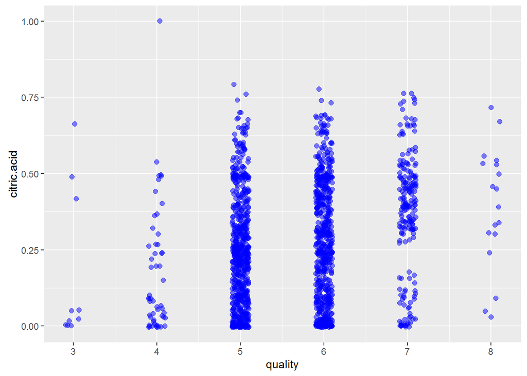

Here is the box plot of citric acide for each quality levels (X is the position of mean) :

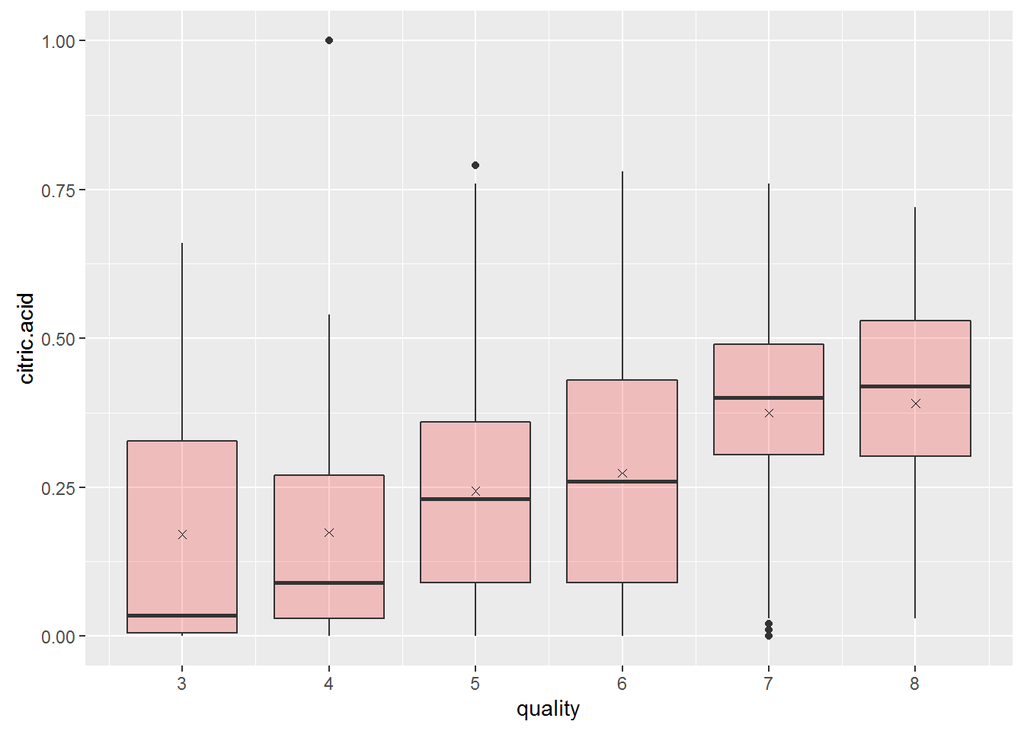

Althought the citric acid for each quality level is widely distributed, it is more likely that wine with higer containing of citric acid have better quality.

The following is the statistic summary of citric acid by quality level.

```
## $`3`
##    Min. 1st Qu.  Median    Mean 3rd Qu.    Max.
##  0.0000  0.0050  0.0350  0.1710  0.3275  0.6600
##
## $`4`
##    Min. 1st Qu.  Median    Mean 3rd Qu.    Max.
##  0.0000  0.0300  0.0900  0.1742  0.2700  1.0000
##
## $`5`
##    Min. 1st Qu.  Median    Mean 3rd Qu.    Max.
##  0.0000  0.0900  0.2300  0.2437  0.3600  0.7900
##
## $`6`
##    Min. 1st Qu.  Median    Mean 3rd Qu.    Max.
##  0.0000  0.0900  0.2600  0.2738  0.4300  0.7800
##
## $`7`
##    Min. 1st Qu.  Median    Mean 3rd Qu.    Max.
##  0.0000  0.3050  0.4000  0.3752  0.4900  0.7600
##
## $`8`
##    Min. 1st Qu.  Median    Mean 3rd Qu.    Max.
##  0.0300  0.3025  0.4200  0.3911  0.5300  0.7200
```

5. Total sulfur dioxide

Here is the scatter plot of total sulfur dioxide for each quality levels:

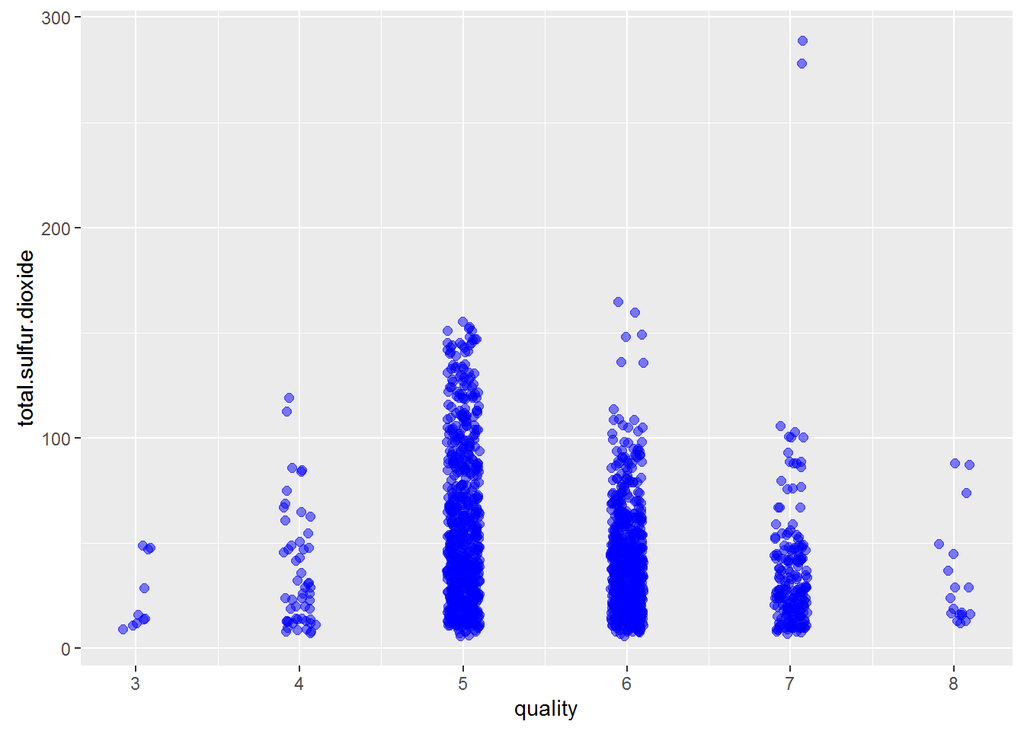

Here is the box plot of total sulfur dioxide for each quality levels (X is the position of mean) :

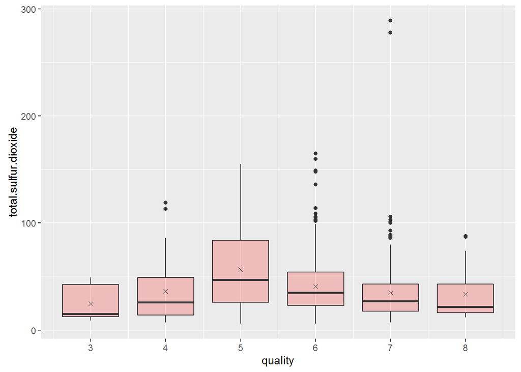

This is an interested result, seems to me, the total sulfer dioxide has a more complicated relationship with quality level. highest total sulfer dioxide correlate to the middle level of quality. And lower concentration correlate to both low and high quality. However, the level 7 has the highest containing of total sulfer dioxide. Thus, it may not be a good feature for prediction of wine quality.

The following is the statistic summary of total sulfer dioxide by quality level.

```
## $`3`
##    Min. 1st Qu.  Median    Mean 3rd Qu.    Max.
##     9.0    12.5    15.0    24.9    42.5    49.0
##
## $`4`
##    Min. 1st Qu.  Median    Mean 3rd Qu.    Max.
##    7.00   14.00   26.00   36.25   49.00  119.00
##
## $`5`
##    Min. 1st Qu.  Median    Mean 3rd Qu.    Max.
##    6.00   26.00   47.00   56.51   84.00  155.00
##
## $`6`
##    Min. 1st Qu.  Median    Mean 3rd Qu.    Max.
##    6.00   23.00   35.00   40.87   54.00  165.00
##
## $`7`
##    Min. 1st Qu.  Median    Mean 3rd Qu.    Max.
##    7.00   17.50   27.00   35.02   43.00  289.00
##
## $`8`
##    Min. 1st Qu.  Median    Mean 3rd Qu.    Max.
##   12.00   16.00   21.50   33.44   43.00   88.00
```

6. Fixed acidity